# Descriptive Statistics and Data Visualization in R: Central Tendency

2024

## Introduction to Central Tendency

- **Central tendency** measures give us an idea of where the center – i.e., most of the data – of a set of observations lies.
- Common measures include the **sample mean**, **sample median**, and **sample mode**.

## Sample Mean

- The **sample mean** is denoted by \(\overline{\boldsymbol{x}}\).
- It is the average of all observations in a sample.

\[ \begin{align} \overline{\boldsymbol{x}} &= \frac{x_1 + x_2 + \ldots + x_{n}}{n}\\ &= \frac{1}{n} \sum_{i=1}^{n} x_{i} \end{align} \]

## Sample Mean Example

- Sample \(\boldsymbol{x} = 55 + 35 + 23 + 44 + 31\)
- The sample mean is: \[ \begin{align} \overline{\boldsymbol{x}} &= \frac{55 + 35 + 23 + 44 + 31}{5}\\ &= \frac{188}{5}\\ &= 37.6 \end{align} \]

## The `mean` function in R

```r
# define a vector of observations
x <- c(55, 35, 23, 44, 31)

# calculate the mean
mean(x)
```

```
## [1] 37.6
```

## Sample Mean visualisation: One sample

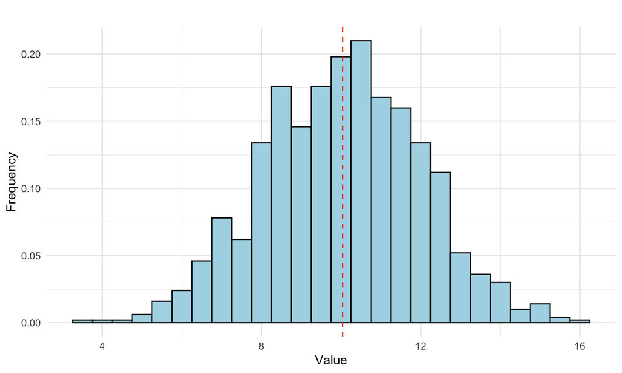

## Sample Mean visualisation: Two samples

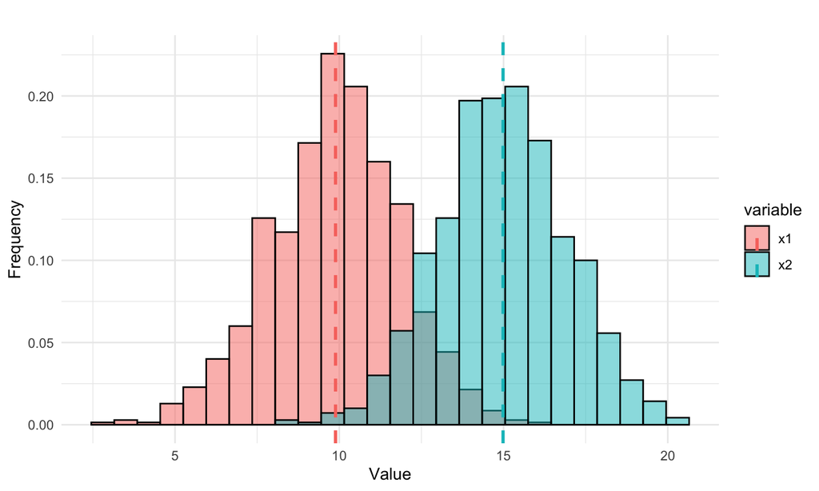

## Sample Median

- The **sample median** is denoted by \(\widetilde{\boldsymbol{x}}\).
- It is the middle value of a dataset when ordered from least to greatest.
- For an even number of observations, it’s the average of the two middle numbers.

## Sample Median Example

- Sample \(\boldsymbol{x} = 55, 35, 23, 44, 31\)
- Ordered sample \(\boldsymbol{x} = 23, 31, 35, 44, 55\)
- The sample median is: \[ \begin{align} \widetilde{\boldsymbol{x}} &= 35 \end{align} \]

## Sample Median Example with Even Observations

- Sample \(\boldsymbol{x} = 55, 35, 23, 44\)
- Ordered sample \(\boldsymbol{x} = 23, 35, 44, 55\)
- The sample median is: \[ \begin{align} \widetilde{\boldsymbol{x}} &= \frac{35 + 44}{2}\\ &= 39.5 \end{align} \]

## The `median` function in R

```r
# define a vector of observations
x <- c(55, 35, 23, 44, 31)

# calculate the median
median(x)
```

```
## [1] 35
```

## Sample Median visualisation: One sample

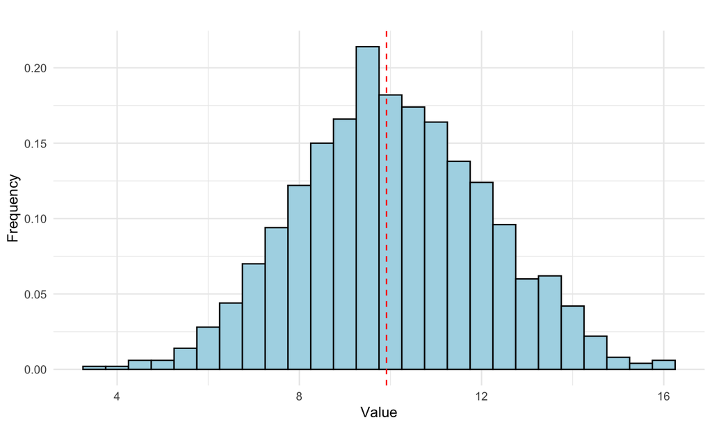

## Sample Median visualisation: Two samples

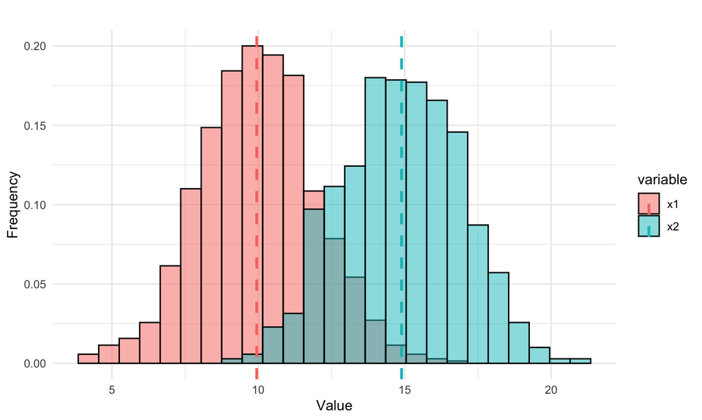

## Means vs Medians With Skewed Distribution

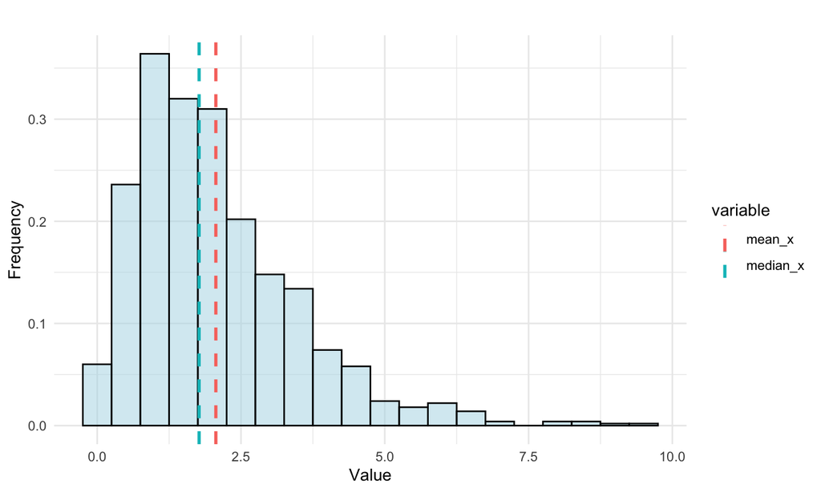

## Central Tendency and Outliers

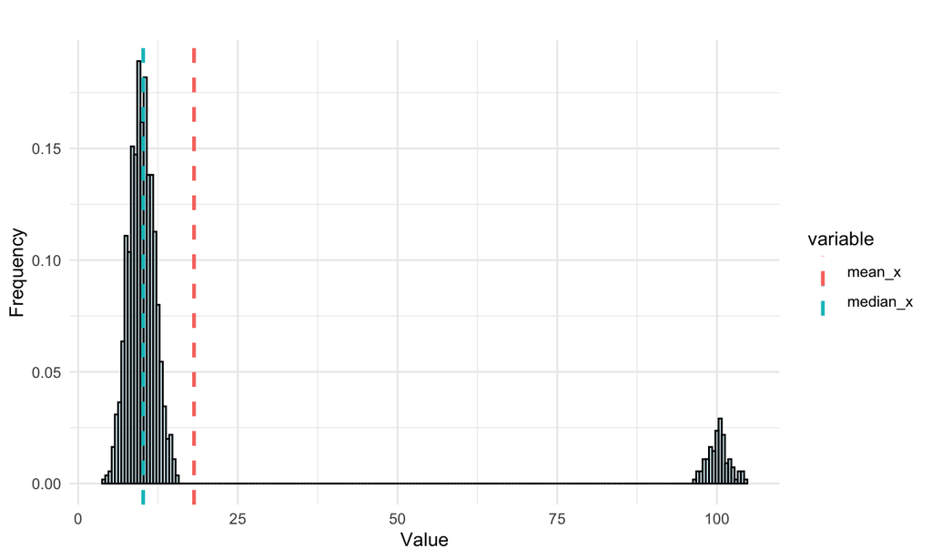

## Sample Mode

- The **sample mode** is the most frequently occurring value in the dataset.
- A dataset may have one mode, more than one mode, or no mode at all.

## Sample Mode Example

- Sample \(\boldsymbol{x} = 55, 35, 23, 44, 31, 55, 55\)
- The sample mode is: \[ \begin{align} \text{mode}(\boldsymbol{x}) &= 55 \end{align} \]

## Sample Mode Example with Multiple Modes

- Sample \(\boldsymbol{x} = 55, 35, 23, 44, 31, 55, 55, 35, 35\)
- The sample mode is: \[ \begin{align} \text{mode}(\boldsymbol{x}) &= 55, 35 \end{align} \]

## Sample Mode Example with No Mode

- Sample \(\boldsymbol{x} = 55, 35, 23, 44, 31\)
- The sample mode is: \[ \begin{align} \text{mode}(\boldsymbol{x}) &= \text{No mode} \end{align} \]

## Sample Mode visualisation: One sample

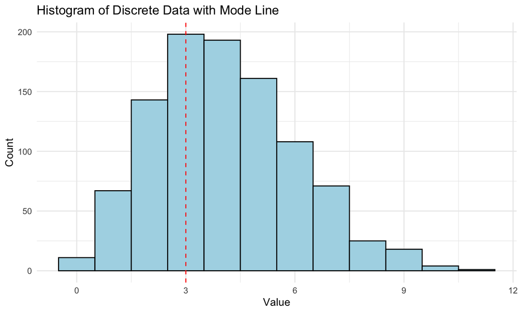

## Sample Mode visualisation: Two samples

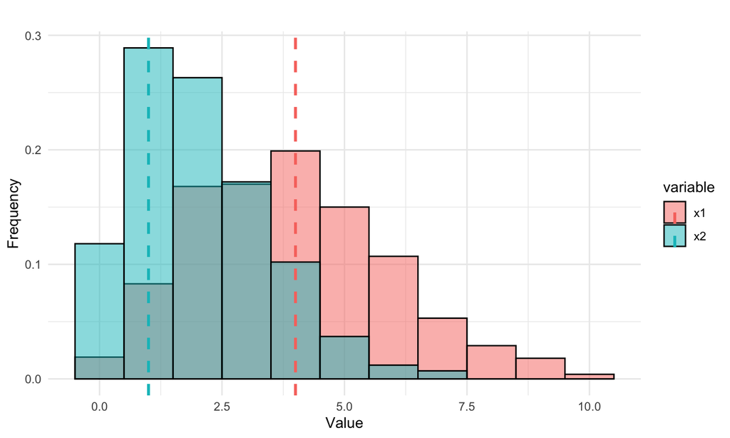

## Question

Consider the following histrogram of a sample of data:

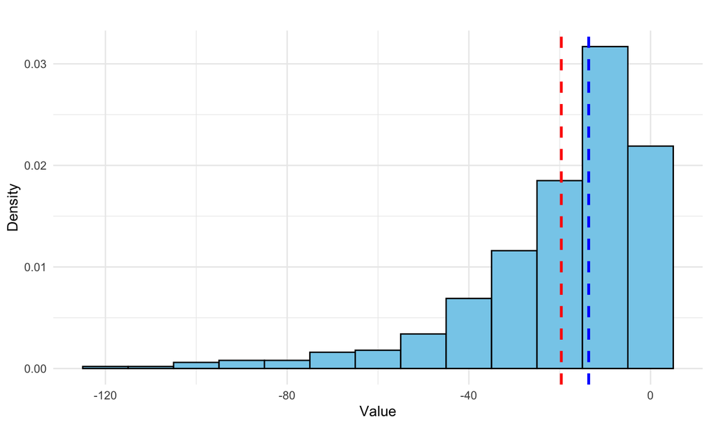

Which of the following statements is true?

- The red line is the mean and the blue line is the median.
- The blue line is the mean and the red line is the median.
- The red line is the mean and the median is not shown.
- The blue line is the mean and the median is not shown.

**Click here for the answer**

**Correct Answer:** A) The red line is the mean and the blue line is the median.

## Question

Consider the following histogram of a sample of data:

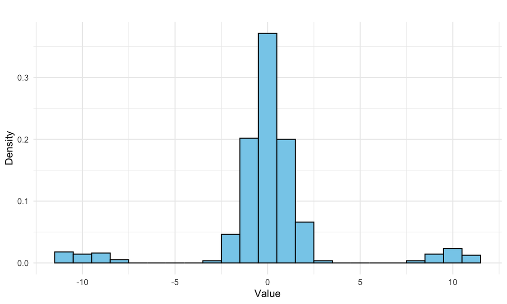

Which of the following statements is true?

- The mean is greater than the median.
- The mean is less than the median.
- The mean is about equal to the median.
- The mean and median cannot be calculated in this sample.